# Лабораторная работа №11

Управление загрузкой системы

Чекмарев Александр Дмитриевич | Группа НПИбд-03-24

Российский университет дружбы народов, Москва, Россия

15 Ноября 2025

# Информация

## Докладчик

- Чекмарев Александр Дмитриевич
- Группа НПИбд-03-24
- Российский университет дружбы народов
- https://github.com/nenokixd?tab=repositories

# Вводная часть

## Цель работы

Получить навыки работы с загрузчиком системы GRUB2

## Задание

1. Продемонстрировать навыки по изменению параметров GRUB и записи изменений в файл конфигурации
2. Продемонстрировать навыки устранения неполадок при работе с GRUB
3. Продемонстрировать навыки работы с GRUB без использования root

# Выполнение лабораторной работы

## Модификация параметров GRUB2

- Запускаем терминала и получаем полномочия администратора.
- В файле /etc/default/grub устанавливаем параметр отображения меню загрузки в течение 10 секунд: **GRUB_TIMEOUT=10**

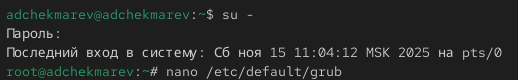

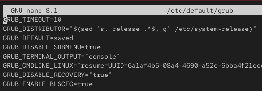

## Модификация параметров GRUB2

- Запишим изменения в GRUB2, введя в командной строке **grub2-mkconfig > /boot/grub2/grub.cfg**

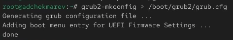

## Модификация параметров GRUB2

- Перезагружаем систему.
- При загрузке системы мы увидим прокрутку загрузочных сообщений

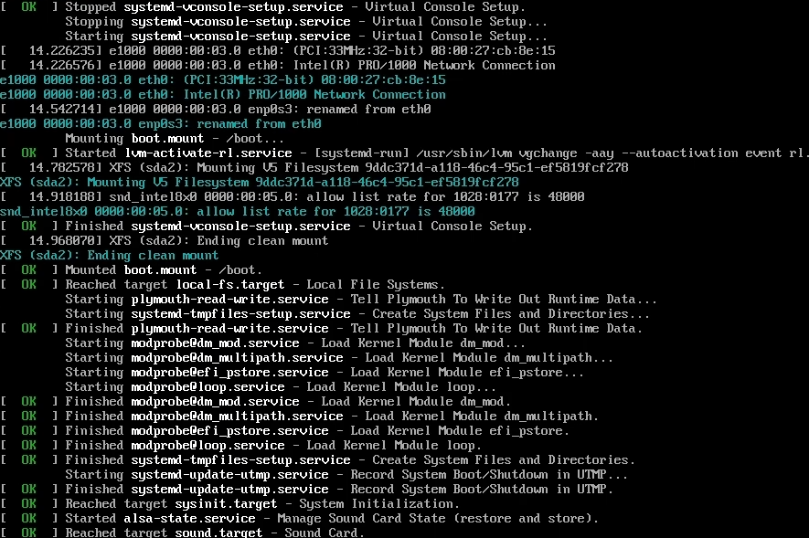

## Модификация параметров GRUB2

- После загрузочных сообщений увидим меню grub с изменённым таймером

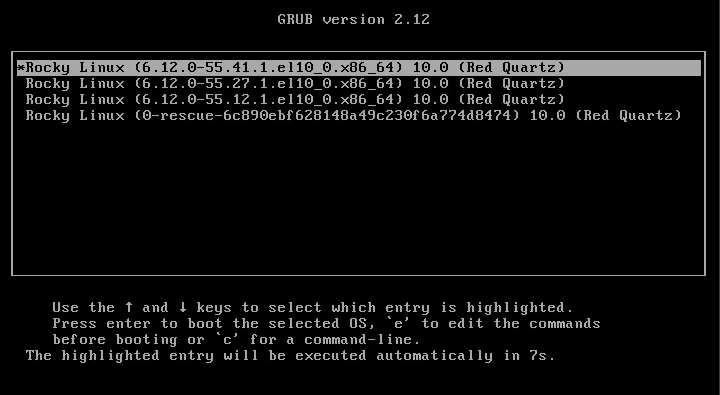

## Устранения неполадок

- Перезагружаем систему. Как только появляется меню GRUB, выбираем строку с текущей версией ядра в меню и нажимаем **e** для редактирования.
- Прокручиваем вниз до строки, начинающейся с linux ($root)/vmlinuz-.
- Эта строка загружает ядро системы. В конце этой строки вводим **systemd.unit=rescue.target** и удаляем опции **rhgb** и **quit** из этой строки.

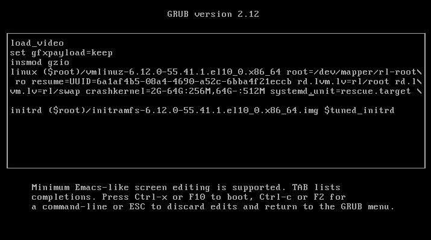

## Устранения неполадок

- Для продолжения загрузки нажимаем **ctrl+x**. После этого вводим пароль пользователя root при появлении запроса
- Посмотрим список всех файлов модулей, которые загружены в настоящее время: **systemctl list-units**

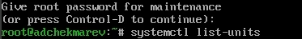

## Модификация параметров GRUB2

- Мы видим, что загружена базовая системная среда

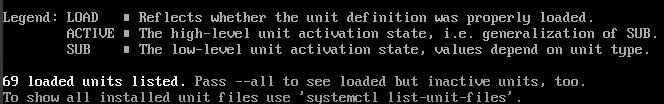

## Устранения неполадок

- Посмотрим задействованные переменные среды оболочки: **systemctl show-environment**

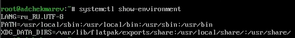

## Устранения неполадок

- Перезагружаем систему, используя команду **systemctl reboot**
- Снова открываем меню GRUB в режиме редактора. В конце строки, загружающей ядро, вводим **systemd.unit=emergency.target**, удаляем опции **rhgb** и **quit** из этой строки.

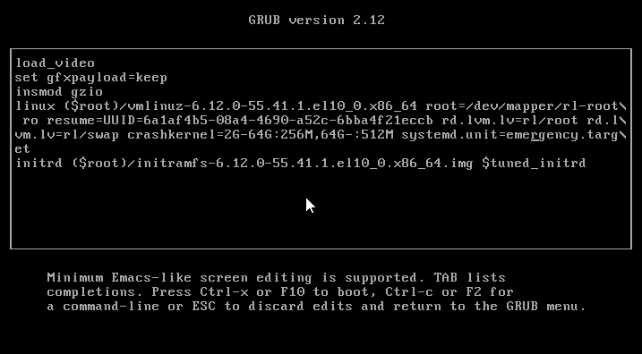

## Устранения неполадок

- Снова вводим пароль пользователя root. После успешного входа в систему смотрим список всех загруженных файлов модулей: **systemctl list-units**.

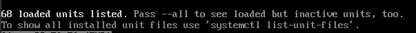

## Сброс пароля root

- Обычный сценарий для администратора Linux заключается в том, что пароль root отсутствует. Если это произойдёт, вам необходимо сбросить его. Единственный способ сделать это — загрузить систему в минимальном режиме, который позволяет войти в систему без ввода пароля. Для этого выполните следующие действия.
- Когда отобразится меню GRUB, выберем в меню строку с текущей версией ядра системы и нажмем e , чтобы войти в режим редактора.
- В конце строки, загружающей ядро, введем **rd.break** и удалим опции **rhgb** и **quit** из этой строки.

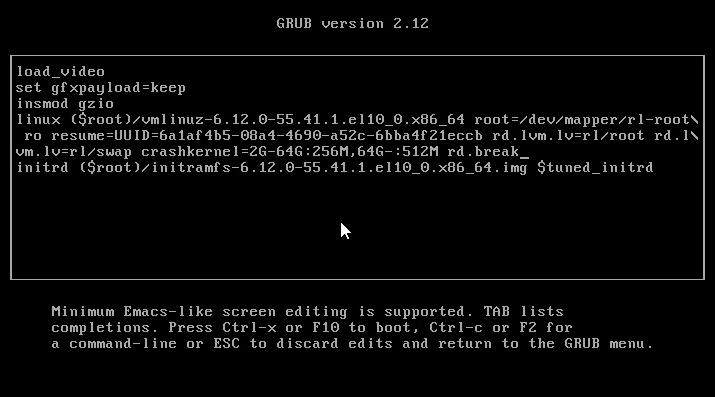

## Сброс пароля root

- Этап загрузки системы остановится в момент загрузки initramfs, непосредственно перед монтированием корневой файловой системы в каталоге /.
- Чтобы получить доступ к системному образу для чтения и записи, набираем **mount -o remount,rw /sysroot**
- Сделаем содержимое каталога /sysimage новым корневым каталогом, набрав **chroot /sysroot**
- Теперь мы можем ввести команду задания пароля: **passwd**. Установим новый пароль для пользователя root

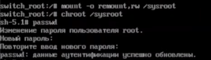

## Сброс пароля root

- Поскольку на этом очень раннем этапе загрузки SELinux ещё не активирован, то тип контекста SELinux для файла /etc/shadow будет испорчен.
- Если мы перезагрузимся в этот момент, то никто не сможет войти в систему. Поэтому мы должны убедиться, что тип контекста установлен правильно.
- Чтобы сделать это, на этом этапе мы загружаем политику SELinux с помощью команды **load_policy -i**

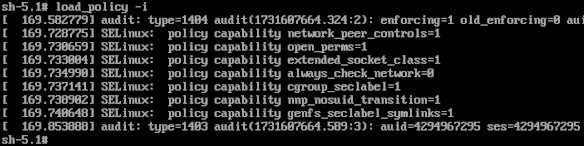

## Сброс пароля root

- Теперь мы можем вручную установить правильный тип контекста для /etc/shadow. Для этого вводим **chcon -t shadow_t /etc/shadow**
- Перезагрузим операционную систему с помощью **reboot -f**
- Опция -f (–force) означает принудительную немедленную остановку, выключение или перезагрузку. При указании один раз это приводит к немедленному, но чистому завершению работы системным менеджером. Если указано дважды, это приводит к немедленному завершению работы без обращения к системному менеджеру
- Теперь можем зайти в учётную запись пользователя root, с помощью нового пароля.

# Подведение итогов

## Выводы

В ходе выполнения лабораторной работы мы получили навыки работы с загрузчиком системы GRUB2